# TFM

Predicción de la mortalidad de aves rapaces en parques eólicos aplicando técnicas de aprendizaje automático

Pablo Casares Gaona

13 de enero, 2025

# Obtención de los datos

Cargamos le dataset y mostramos su estrcutura:

```r
> datos_iniciales <- read_xlsx(params$myfile)
> str(datos_iniciales)
```

```
tibble [6,392 × 28] (S3: tbl_df/tbl/data.frame)
 $ Id                    : num [1:6392] 1.94e+02 2.08e+08 2.08e+08 2.08e+08 2.08e+08 ...
 $ id_proyecto           : num [1:6392] 238 238 238 238 238 238 238 238 238 238 ...
 $ Contactos             : chr [1:6392] "Muertos" "Vivos" "Vivos" "Vivos" ...
 $ Fecha                 : POSIXct[1:6392], format: "2021-02-23" "2021-02-25" ...
 $ Mes                   : chr [1:6392] "Febrero" "Febrero" "Febrero" "Febrero" ...
 $ Estación              : chr [1:6392] "Primavera" "Primavera" "Primavera" "Primavera" ...
 $ Hora                  : POSIXct[1:6392], format: "1899-12-31 11:06:00" "1899-12-31 15:16:00" ...
 $ Longitud              : num [1:6392] -2.58 -2.58 -2.57 -2.57 -2.58 ...
 $ Latitud               : num [1:6392] 39 39 39 39 39 ...
 $ Altitud               : num [1:6392] NA NA NA NA NA NA NA NA NA NA ...
 $ Especie               : num [1:6392] 2390 3040 2390 2390 2390 2390 2390 2390 2870 2390 ...
 $ Nombre_científico     : chr [1:6392] "Milvus milvus" "Falco tinnunculus" "Milvus milvus" "Milvus milvus" ...
 $ Nombre_común          : chr [1:6392] "Milano real" "Cernícalo Vulgar" "Milano Real" "Milano Real" ...
 $ distancia             : num [1:6392] 200 NA NA NA NA 10 NA NA NA NA ...
 $ orientacion           : chr [1:6392] "--" NA NA NA ...
 $ Edad                  : chr [1:6392] "Adulto" "Sin especificar" "Sin especificar" "Sin especificar" ...
 $ Sexo                  : chr [1:6392] "Indeterminado" "Indeterminado" "Indeterminado" "Indeterminado" ...
 $ permanencia           : chr [1:6392] "Más de 30 días" NA NA NA ...
 $ ALA                   : num [1:6392] NA NA NA NA NA NA NA NA NA NA ...
 $ PESO                  : logi [1:6392] NA NA NA NA NA NA ...
 $ GRASA                 : logi [1:6392] NA NA NA NA NA NA ...
 $ MUSCULO               : logi [1:6392] NA NA NA NA NA NA ...
 $ tipo_mortalidad       : chr [1:6392] "Mortalidad directa" NA NA NA ...
 $ ANTEBRAZO             : logi [1:6392] NA NA NA NA NA NA ...
 $ estado_cuerpo         : chr [1:6392] "Cadáver reseco-en esqueleto" NA NA NA ...
 $ Número_Aerogeneradores: num [1:6392] 34 34 34 34 34 34 34 34 34 34 ...
 $ Potencia_unitaria     : num [1:6392] 1500 1500 1500 1500 1500 1500 1500 1500 1500 1500 ...
 $ Diámetro              : num [1:6392] 77 77 77 77 77 77 77 77 77 77 ...
```

Observamos que nuestro dataset presenta 6392 observaciones y 28 variables.

Mostramos un resumen de cada variable del dataset:

```r
> summary(datos_iniciales)
```

```
       Id             id_proyecto     Contactos
 Min.   :        0   Min.   :228.0   Length:6392
 1st Qu.:245471218   1st Qu.:238.0   Class :character
 Median :265699730   Median :380.0   Mode  :character
 Mean   :231947124   Mean   :361.8
 3rd Qu.:283575111   3rd Qu.:478.0
 Max.   :331927672   Max.   :478.0

     Fecha                            Mes              Estación
 Min.   :2021-02-23 00:00:00.00   Length:6392        Length:6392
 1st Qu.:2022-12-01 00:00:00.00   Class :character   Class :character
 Median :2023-05-19 00:00:00.00   Mode  :character   Mode  :character
 Mean   :2023-05-11 22:01:03.07
 3rd Qu.:2023-11-13 00:00:00.00
 Max.   :2024-10-24 00:00:00.00

      Hora                           Longitud           Latitud
 Min.   :1899-12-31 00:10:00.00   Min.   :    -2.6   Min.   :     -3
 1st Qu.:1899-12-31 10:19:00.00   1st Qu.:    -2.6   1st Qu.:     39
 Median :1899-12-31 11:24:00.00   Median :    -2.3   Median :     40
 Mean   :1899-12-31 11:44:00.40   Mean   : 16157.4   Mean   : 120473
 3rd Qu.:1899-12-31 12:49:00.00   3rd Qu.:    -2.2   3rd Qu.:     40
 Max.   :1899-12-31 23:56:00.00   Max.   :649581.0   Max.   :4428032

    Altitud          Especie     Nombre_científico  Nombre_común
 Min.   :   0.0   Min.   :   0   Length:6392        Length:6392
 1st Qu.:  55.0   1st Qu.:2390   Class :character   Class :character
 Median :  55.0   Median :2600   Mode  :character   Mode  :character
 Mean   : 392.7   Mean   :2808
 3rd Qu.: 863.0   3rd Qu.:2960
 Max.   :1085.0   Max.   :7680
 NA's   :6267     NA's   :216
   distancia      orientacion            Edad               Sexo
 Min.   :  0.00   Length:6392        Length:6392        Length:6392
 1st Qu.: 30.00   Class :character   Class :character   Class :character
 Median : 50.00   Mode  :character   Mode  :character   Mode  :character
 Mean   : 56.79
 3rd Qu.: 80.00
 Max.   :200.00
 NA's   :6193
```

[output cut: 8 more lines]

```
 MUSCULO        tipo_mortalidad    ANTEBRAZO      estado_cuerpo
 Mode:logical   Length:6392        Mode:logical   Length:6392
 NA's:6392      Class :character   NA's:6392      Class :character
                Mode  :character                  Mode  :character




 Número_Aerogeneradores Potencia_unitaria    Diámetro
 Min.   : 9.00          Min.   : 800      Min.   : 52.0
 1st Qu.:19.00          1st Qu.:2000      1st Qu.: 90.0
 Median :19.00          Median :4500      Median :149.1
 Mean   :34.27          Mean   :3824      Mean   :127.4
 3rd Qu.:69.00          3rd Qu.:5500      3rd Qu.:158.0
 Max.   :69.00          Max.   :5500      Max.   :158.0
```

Para hacernos una idea de como son las observaciones de este dataset podemos mostrar las primeras observaciones del mismo:

```r
> head(datos_iniciales)
```

| Id | id_proyecto | Contactos | Fecha | Mes | Estación | Hora | Longitud | Latitud | Altitud | Especie | Nombre_científico | Nombre_común | distancia | orientacion | Edad | Sexo | permanencia | ALA | PESO | GRASA | MUSCULO | tipo_mortalidad | ANTEBRAZO | estado_cuerpo | Número_Aerogeneradores | Potencia_unitaria | Diámetro |
| --- | --- | --- | --- | --- | --- | --- | --- | --- | --- | --- | --- | --- | --- | --- | --- | --- | --- | --- | --- | --- | --- | --- | --- | --- | --- | --- | --- |
| 194 | 238 | Muertos | 2021-02-23 | Febrero | Primavera | 1899-12-31 11:06:00 | -2.584580 | 39.01005 | NA | 2390 | Milvus milvus | Milano real | 200 | -- | Adulto | Indeterminado | Más de 30 días | NA | NA | NA | NA | Mortalidad directa | NA | Cadáver reseco-en esqueleto | 34 | 1500 | 77 |
| 207876796 | 238 | Vivos | 2021-02-25 | Febrero | Primavera | 1899-12-31 15:16:00 | -2.577790 | 39.00497 | NA | 3040 | Falco tinnunculus | Cernícalo Vulgar | NA | NA | Sin especificar | Indeterminado | NA | NA | NA | NA | NA | NA | NA | NA | 34 | 1500 | 77 |
| 207876797 | 238 | Vivos | 2021-02-25 | Febrero | Primavera | 1899-12-31 12:00:00 | -2.569681 | 39.01445 | NA | 2390 | Milvus milvus | Milano Real | NA | NA | Sin especificar | Indeterminado | NA | NA | NA | NA | NA | NA | NA | NA | 34 | 1500 | 77 |
| 207876797 | 238 | Vivos | 2021-02-25 | Febrero | Primavera | 1899-12-31 12:00:00 | -2.569681 | 39.01445 | NA | 2390 | Milvus milvus | Milano Real | NA | NA | Sin especificar | Indeterminado | NA | NA | NA | NA | NA | NA | NA | NA | 34 | 1500 | 77 |
| 207876798 | 238 | Vivos | 2021-02-25 | Febrero | Primavera | 1899-12-31 11:06:00 | -2.584577 | 39.01005 | NA | 2390 | Milvus milvus | Milano Real | NA | NA | Sin especificar | Indeterminado | NA | NA | NA | NA | NA | NA | NA | NA | 34 | 1500 | 77 |
| 195 | 238 | Muertos | 2021-03-18 | Marzo | Primavera | 1899-12-31 14:15:00 | -2.560180 | 38.96685 | NA | 2390 | Milvus milvus | Milano real | 10 | -- | Adulto | Indeterminado | Más de 30 días | NA | NA | NA | NA | Mortalidad directa | NA | Restos | 34 | 1500 | 77 |

# Limpieza y transformación de los datos

Eliminaremos las columnas con información supeflua como “tipo_mortalidad” o “Id”, columnas con información redundante como “Fecha” y las columnas que apenas contienen datos como “MUSCULO” o “ANTEBRAZO”. Estas últimas columnas podrían servir para futuros proyectos si se tomaran los datos correspondientes para todas las observaciones.

```r
> datos <- datos_iniciales %>% select(-Id, , -id_proyecto, -Fecha, -Longitud, -Latitud,
+                                     -Altitud, -Especie, -distancia, -orientacion,
+                                     -Nombre_científico, -permanencia, -ALA, -PESO,
+                                     -GRASA, -MUSCULO, -tipo_mortalidad, -ANTEBRAZO,
+                                     -estado_cuerpo)
> datos
```

| Contactos | Mes | Estación | Hora | Nombre_común | Edad | Sexo | Número_Aerogeneradores | Potencia_unitaria | Diámetro |
| --- | --- | --- | --- | --- | --- | --- | --- | --- | --- |
| Muertos | Febrero | Primavera | 1899-12-31 11:06:00 | Milano real | Adulto | Indeterminado | 34 | 1500 | 77.0 |
| Vivos | Febrero | Primavera | 1899-12-31 15:16:00 | Cernícalo Vulgar | Sin especificar | Indeterminado | 34 | 1500 | 77.0 |
| Vivos | Febrero | Primavera | 1899-12-31 12:00:00 | Milano Real | Sin especificar | Indeterminado | 34 | 1500 | 77.0 |
| Vivos | Febrero | Primavera | 1899-12-31 12:00:00 | Milano Real | Sin especificar | Indeterminado | 34 | 1500 | 77.0 |
| Vivos | Febrero | Primavera | 1899-12-31 11:06:00 | Milano Real | Sin especificar | Indeterminado | 34 | 1500 | 77.0 |
| Muertos | Marzo | Primavera | 1899-12-31 14:15:00 | Milano real | Adulto | Indeterminado | 34 | 1500 | 77.0 |
| Vivos | Marzo | Primavera | 1899-12-31 14:15:00 | Milano Real | Sin especificar | Indeterminado | 34 | 1500 | 77.0 |
| Vivos | Marzo | Primavera | 1899-12-31 13:42:00 | Milano Real | Sin especificar | Indeterminado | 34 | 1500 | 77.0 |
| Vivos | Marzo | Primavera | 1899-12-31 11:09:00 | Busardo Ratonero | Sin especificar | Indeterminado | 34 | 1500 | 77.0 |
| Vivos | Marzo | Primavera | 1899-12-31 10:14:00 | Milano Real | Sin especificar | Indeterminado | 34 | 1500 | 77.0 |

[output cut: 6382 more lines]

Ahora tranformamos los datos al formato correcto para proceder con los análisis:

```r
> # Asegurar que "Contactos", "Estación", "Edad" y "Sexo" sean factores
> datos$Contactos <- factor(datos$Contactos, levels = c("Vivos", "Muertos"))
> datos$Estación <- factor(datos$Estación)
> datos$Edad <- factor(datos$Edad, levels = c("Pollo", "Juvenil", "Adulto",
+                                             "Sin especificar"))
> datos$Sexo <- factor(datos$Sexo, levels = c("Macho", "Hembra", "Indeterminado"))
```

# Análisis exploratorio

## Frecuencia de contactos

Mostramos la cantidad de observaciones que hay de individuos vivos y la cantidad de contactos de mortalidad que se han producido.

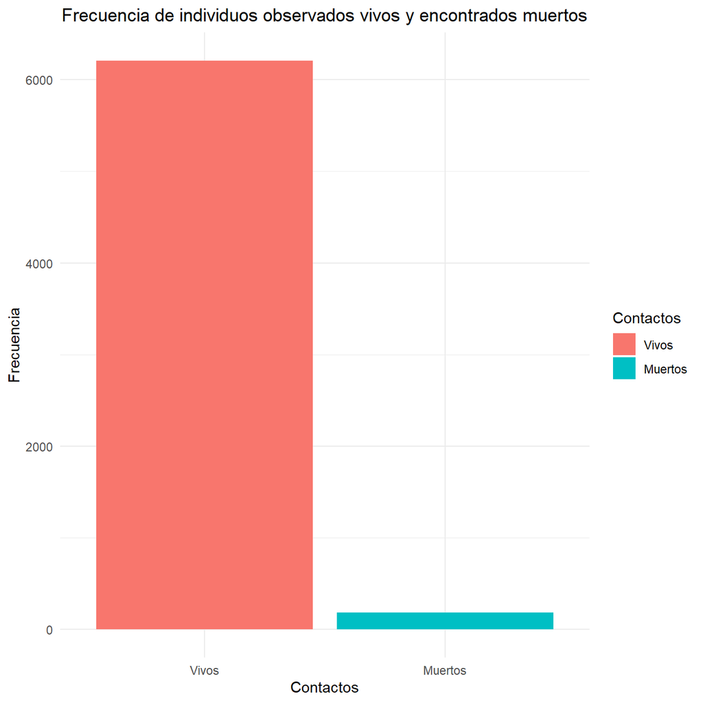

```r
> # Tabla de frecuencia de contactos
> tabla_contactos <- datos %>%
+   group_by(Contactos) %>%
+   summarise(Frecuencia = n())
>
> # Gráfico de Contactos
> ggplot(tabla_contactos, aes(x = Contactos, y = Frecuencia, fill = Contactos)) +
+   geom_bar(stat = "identity") +
+   labs(title = "Frecuencia de individuos observados vivos y encontrados muertos",
+        x = "Contactos", y = "Frecuencia") +
+   theme_minimal() +
+   theme(plot.title = element_text(hjust = 0.5))
```

Observamos la mayor presencia de individuos observados vivos que de contactos de individuos muertos (lo esperado).

## Mortalidad por estación

También mostramos la distribución de la mortalidad según la estación del año.

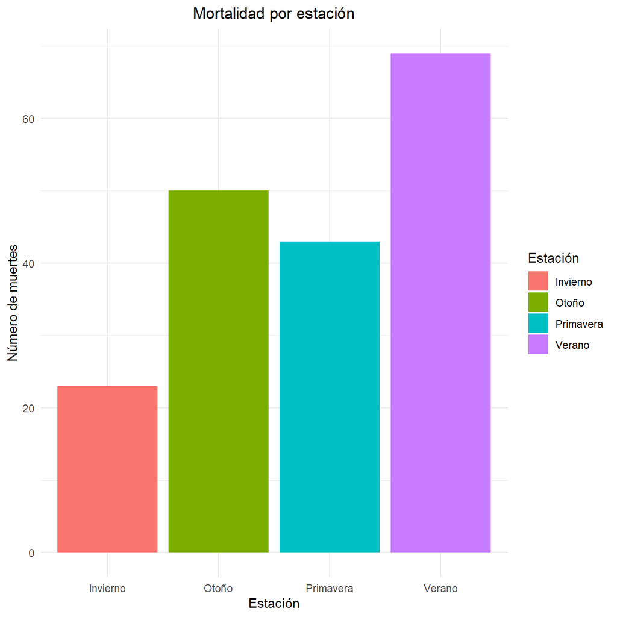

```r
> # Tabla y gráfico de mortalidad por estación
> tabla_estacion <- datos %>%
+   filter(Contactos == "Muertos") %>%
+   group_by(Estación) %>%
+   summarise(Mortalidad = n())
>
> ggplot(tabla_estacion, aes(x = Estación, y = Mortalidad, fill = Estación)) +
+   geom_bar(stat = "identity") +
+   labs(title = "Mortalidad por estación", x = "Estación", y = "Número de muertes") +
+   theme_minimal() +
+   theme(plot.title = element_text(hjust = 0.5))
```

La estación con mayor mortalidad es verano y la estación con menor mortalidad es invierno.

## Comparación de mortalidad entre estaciones

La prueba de Chi-cuadrado nos permite determinar si existe una relación significativa entre dos variables categóricas, en este caso la mortalidad y la estación del año.

```r
> tabla_mortalidad_estacion <- table(datos$Contactos, datos$Estación)
>
> # Prueba de Chi-cuadrado
> chisq.test(tabla_mortalidad_estacion)
```

```
    Pearson's Chi-squared test

data:  tabla_mortalidad_estacion
X-squared = 28.296, df = 3, p-value = 3.149e-06
```

El p-valor menor de 0,05 nos indica que existe una relación significativa entre la mortalidad y la estación del año, confirmando lo observado en el gráfico del apartado anterior.

## Distribución por especie y mortalidad

También podemos mostrar la distribución de la mortalidad según la especie.

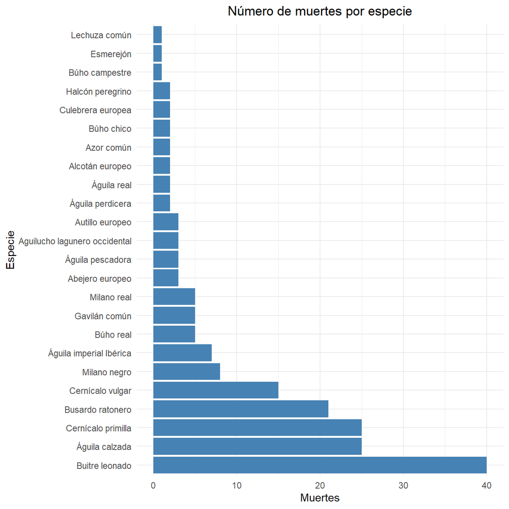

```r
> # Tabla y gráfico de especies muertas
> tabla_especie <- datos %>%
+   filter(Contactos == "Muertos") %>%
+   group_by(`Nombre_común`) %>%
+   summarise(Muertes = n()) %>%
+   arrange(desc(Muertes))
>
> ggplot(tabla_especie, aes(x = reorder(`Nombre_común`, -Muertes), y = Muertes)) +
+   geom_bar(stat = "identity", fill = "steelblue") +
+   labs(title = "Número de muertes por especie", x = "Especie", y = "Muertes") +
+   coord_flip() +
+   theme_minimal() +
+   theme(plot.title = element_text(hjust = 0.5))
```

La especie con mayor mortalidad es el buitre leonado, coincidiendo con datos de otros estudios.

## Distribución de la mortalidad según el diámetro de los aerogeneradores

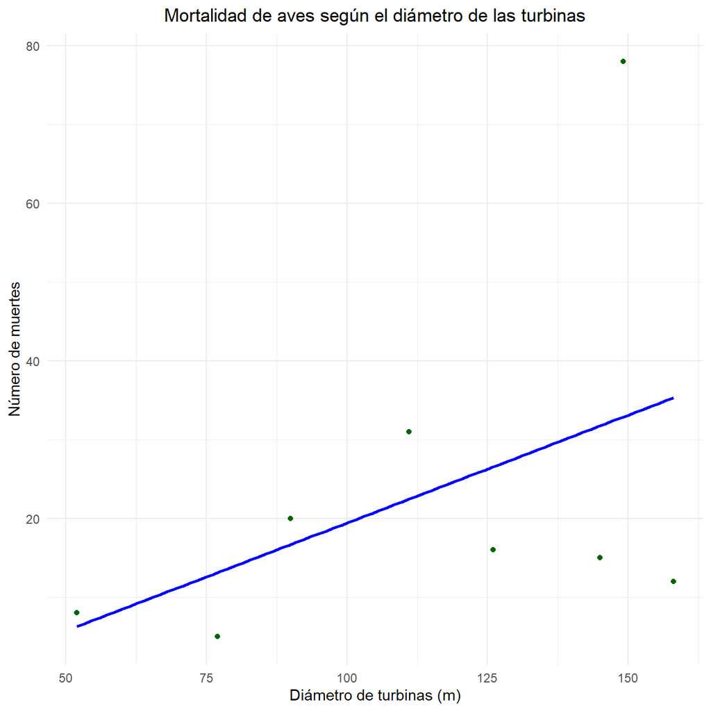

```r
> # Calcular mortalidad media por diámetro de turbinas
> mortalidad_diametro <- datos %>%
+   filter(Contactos == "Muertos") %>%
+   group_by(Diámetro) %>%
+   summarise(Mortalidad = n())
>
> # Gráfico de mortalidad por diámetro de turbinas
> ggplot(mortalidad_diametro, aes(x = Diámetro, y = Mortalidad)) +
+   geom_point(color = "darkgreen") +
+   geom_smooth(method = "lm", se = FALSE, color = "blue") +
+   labs(title = "Mortalidad de aves según el diámetro de las turbinas",
+        x = "Diámetro de turbinas (m)", y = "Número de muertes") +
+   theme_minimal() +
+   theme(plot.title = element_text(hjust = 0.5))
```

Parece haber una tendencia que indica que a mayor diámetro de las turbinas eólicas mayor será la mortalidad.

# Preprocesado de datos

## Tratamiento de datos faltantes

Primero comprobamos si hay datos faltantes:

```r
> sum(is.na(datos))
```

```
[1] 0
```

Puesto que no hay datos faltantes no es necesario realizar ningún tratamiento en este sentido.

## Creación de nuevas variables

Podemos dividir la variable “Hora” en periodos de tiempo como “día”, “tarde” y “noche”:

```r
> # Crear una nueva variable 'Periodo_dia' basada en la hora
> datos$Periodo_dia <- cut(as.numeric(format(datos$Hora, "%H")),
+                          breaks = c(-1, 5, 11, 17, 24),
+                          labels = c("Noche", "Mañana", "Tarde", "Noche"),
+                          right = TRUE)
>
> # Eliminamos la columna de Hora
> datos <- datos %>% select(-Hora)
```

## Codificación de variables categóricas

Los modelos de aprendizaje automático requieren que las variables categóricas sean numéricas. Este proceso de asignar un número a cada variable categórica se denomina Label encoding.

```r
> # Convertir los meses a números de 1 a 12
> datos$Mes <- as.numeric(factor(datos$Mes, levels = c("Enero", "Febrero", "Marzo",
+                                                      "Abril", "Mayo", "Junio",
+                                                      "Julio", "Agosto", "Septiembre",
+                                                      "Octubre", "Noviembre", "Diciembre")))
>
> # Convertir las estaciones a números de 1 a 4
> datos$Estación <- as.numeric(factor(datos$Estación, levels = c("Invierno", "Primavera",
+                                                                "Verano", "Otoño")))
>
> # Convertir los nombres de las especies a números
> datos$Nombre_común <- as.numeric(as.factor(datos$Nombre_común))
>
> # Convertir las edades a números
> datos$Edad <- as.numeric(factor(datos$Edad, levels = c("Pollo", "Juvenil", "Adulto",
+                                                        "Sin especificar")))
>
> # Convertir el sexo del individuo a números
> datos$Sexo <- as.numeric(factor(datos$Sexo, levels = c("Macho", "Hembra",
+                                                        "Indeterminado")))
>
> # Convertir el el periodo del día del individuo a números
> datos$Periodo_dia <- as.numeric(factor(datos$Periodo_dia, levels = c("Noche", "Mañana",
+                                                                      "Tarde"), ordered = TRUE))
```

## Identificación y tratmiento de valores atípicos (outliers)

```r
> # Cálculo de IQR para Potencia unitaria
> Q1 <- quantile(datos$Potencia_unitaria, 0.25, na.rm = TRUE)
> Q3 <- quantile(datos$Potencia_unitaria, 0.75, na.rm = TRUE)
> IQR <- Q3 - Q1
>
> # Identificación de outliers
> outliers_potencia <- datos$Potencia_unitaria < (Q1 - 1.5 * IQR) |
+   datos$Potencia_unitaria > (Q3 + 1.5 * IQR)
> cat("Número de outliers en Potencia unitaria:", sum(outliers_potencia), "\n")
```

```
Número de outliers en Potencia unitaria: 0
```

```r
> # Tratamiento de outliers
> datos <- datos[!outliers_potencia, ]
>
> # Cálculo de IQR para Diámetro
> Q1 <- quantile(datos$Diámetro, 0.25, na.rm = TRUE)
> Q3 <- quantile(datos$Diámetro, 0.75, na.rm = TRUE)
> IQR <- Q3 - Q1
>
> # Identificación de outliers
> outliers_diametro <- datos$Diámetro < (Q1 - 1.5 * IQR) | datos$Diámetro >
+   (Q3 + 1.5 * IQR)
> cat("Número de outliers en Diámetro:", sum(outliers_diametro), "\n")
```

```
Número de outliers en Diámetro: 0
```

## División del conjunto de datos de entrenamiento y prueba

Dividiremos el los datos en un 70% de datos de entrenamiento y un 30% de datos de prueba:

```r
> # Establecemos la semilla
> set.seed(12345)
>
> # Dividimos el conjunto de datos en entrenamiento y prueba
> trainIndex <- createDataPartition(datos$Contactos, p = 0.7, list = FALSE)
> datos_train <- datos[trainIndex, ]    # Conjunto de entrenamiento (70% de los datos)
> datos_test <- datos[-trainIndex, ]    # Conjunto de prueba (30% de los datos)
>
> # Verificamos las dimensiones de cada conjunto
> cat("Dimensiones del conjunto de entrenamiento:", dim(datos_train), "\n")
```

```
Dimensiones del conjunto de entrenamiento: 4475 10
```

```r
> cat("Dimensiones del conjunto de prueba:", dim(datos_test), "\n")
```

```
Dimensiones del conjunto de prueba: 1917 10
```

## Balanceo de las clases de mortalidad

Mostramos cuantas observaciones hay en cada clase:

```r
> # Conteo de observaciones en cada clase
> table(datos_train$Contactos)
```

```
  Vivos Muertos
   4345     130
```

Debido al gran desbalanceo procederemos al sobremuestreo de la clase minoritaria y el submuestreo de la clase mayoritaria:

```r
> # Aplicar sobremuestreo a la clase minoritaria
> datos_balanceados <- ROSE(Contactos ~ ., data = datos_train, seed = 12345)$data
>
> # Verificar la nueva distribución de clases
> table(datos_balanceados$Contactos)
```

```
  Vivos Muertos
   2194    2281
```

Podemos observar que la clase minoritaria ha aumentado, permitiendo así tener más datos de esta clase, y la mayoritaria ha disminuido.

## Normalización de variables numéricas

Para evitar que las diferencias de escala entre variables afecten los modelos, conviene normalizar las variables numéricas.

```r
> # Calculamos los mínimos y máximos del conjunto de entrenamiento
> min_potencia <- min(datos_train$Potencia_unitaria)
> max_potencia <- max(datos_train$Potencia_unitaria)
>
> min_diametro <- min(datos_train$Diámetro)
> max_diametro <- max(datos_train$Diámetro)
>
> # Normalizamos las variables numéricas del conjunto de entrenamiento
>
> datos_train$Potencia_unitaria <- (datos_train$Potencia_unitaria - min_potencia) /
+   (max_potencia - min_potencia)
>
> datos_train$Diámetro <- (datos_train$Diámetro - min_diametro) /
+   (max_diametro - min_diametro)
>
> # Normalizamos las variables numéricas del conjunto de prueba
> datos_test$Potencia_unitaria <- (datos_test$Potencia_unitaria - min_potencia) /
+   (max_potencia - min_potencia)
>
> datos_test$Diámetro <- (datos_test$Diámetro - min_diametro) /
+   (max_diametro - min_diametro)
>
> # Verificamos el resultado
>
> summary(datos_train$Potencia_unitaria)
```

```
   Min. 1st Qu.  Median    Mean 3rd Qu.    Max.
 0.0000  0.2553  0.7872  0.6378  1.0000  1.0000
```

```r
> summary(datos_test$Potencia_unitaria)
```

```
   Min. 1st Qu.  Median    Mean 3rd Qu.    Max.
 0.0000  0.2553  0.7872  0.6562  1.0000  1.0000
```

```r
> summary(datos_train$Diámetro)
```

```
   Min. 1st Qu.  Median    Mean 3rd Qu.    Max.
 0.0000  0.3585  0.9160  0.7071  1.0000  1.0000
```

```r
> summary(datos_test$Diámetro)
```

```
   Min. 1st Qu.  Median    Mean 3rd Qu.    Max.
 0.0000  0.3585  0.9160  0.7219  1.0000  1.0000
```

# Tipos de algoritmos

## Regresión logística

```r
> # Ajustamos modelo de regresión logística
> modelo_log <- glm(Contactos ~ ., data = datos_balanceados, family = binomial)
>
> # Predicciones en el conjunto de prueba
> pred_log <- predict(modelo_log, newdata = datos_test, type = "response")
>
> # Convertimos probabilidades en clases
> pred_clases <- ifelse(pred_log > 0.5, "Muertos", "Vivos")
>
> # Evaluamos el modelo
> confusionMatrix(as.factor(pred_clases), datos_test$Contactos)
```

```
Confusion Matrix and Statistics

          Reference
Prediction Vivos Muertos
   Vivos    1322       7
   Muertos   540      48

               Accuracy : 0.7147
                 95% CI : (0.6939, 0.7348)
    No Information Rate : 0.9713
    P-Value [Acc > NIR] : 1

                  Kappa : 0.1022

 Mcnemar's Test P-Value : <2e-16

            Sensitivity : 0.70999
            Specificity : 0.87273
         Pos Pred Value : 0.99473
         Neg Pred Value : 0.08163
             Prevalence : 0.97131
         Detection Rate : 0.68962
   Detection Prevalence : 0.69327
      Balanced Accuracy : 0.79136

       'Positive' Class : Vivos
```

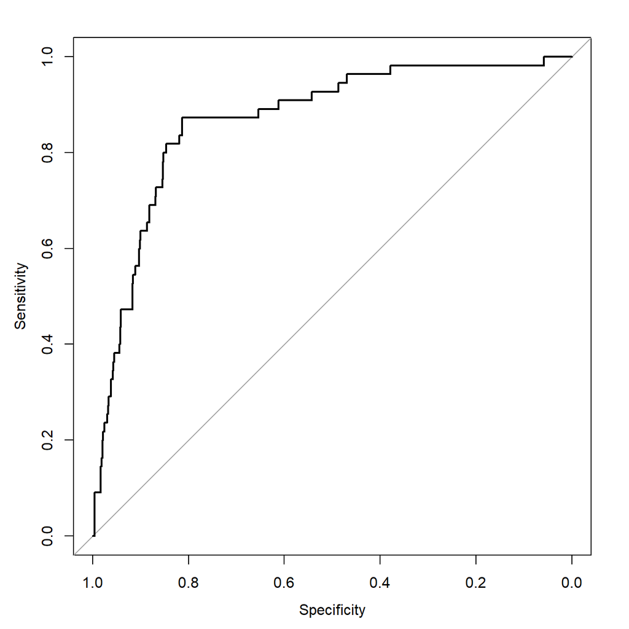

```r
> # Pasamos la variable objetivo a formato numérico
> roc_curve <- roc(datos_test$Contactos, as.numeric(pred_log))
> plot(roc_curve)
```

```r
> auc(roc_curve)
```

```
Area under the curve: 0.8676
```

### Ajuste del modelo de regresión logística

```r
> # Evaluación de multicolinealidad
> # La multicolinealidad puede inflar los coeficientes de las variables. Por ello verificamos el Factor de Inflación de la Varianza (VIF)
>
> vif(modelo_log)
```

```
                   Mes               Estación           Nombre_común
              1.205409               1.213624               1.064810
                  Edad                   Sexo Número_Aerogeneradores
              1.046576               1.031812               1.059099
     Potencia_unitaria               Diámetro            Periodo_dia
              2.313654               2.397244               1.020269
```

Como ninguna variable supera el VIF 5, no eliminamos ninguna.

```r
> # Configuramos validación cruzada
> control <- trainControl(
+   method = "cv",                     # Validación cruzada
+   number = 10,                       # Número de particiones (10-fold CV)
+   classProbs = TRUE,                 # Calcular probabilidades para métricas
+   summaryFunction = twoClassSummary  # Métrica principal (ROC-AUC)
+ )
```

```r
> # Creamos una rejilla con valores de alpha y lambda
> grid <- expand.grid(
+   alpha = c(0, 0.5, 1),          # Ridge (0), Elastic Net (0.5), Lasso (1)
+   lambda = 10^seq(-2, 2, length = 5)  # Lambda en escala logarítmica
+ )
>
> # Entrenamos el modelo con glmnet
> modelo_log2 <- train(
+   Contactos ~ .,                 # Fórmula
+   data = datos_balanceados,      # Datos de entrenamiento
+   method = "glmnet",             # Regresión logística con regularización
+   tuneGrid = grid,               # Rejilla de hiperparámetros
+   trControl = control,           # Validación cruzada
+   metric = "ROC"                 # Maximizar el área bajo la curva ROC
+ )
>
> # Mostramos la mejor combinación de hiperparámetros
> print(modelo_log2$bestTune)
```

```
  alpha lambda
1     0   0.01
```

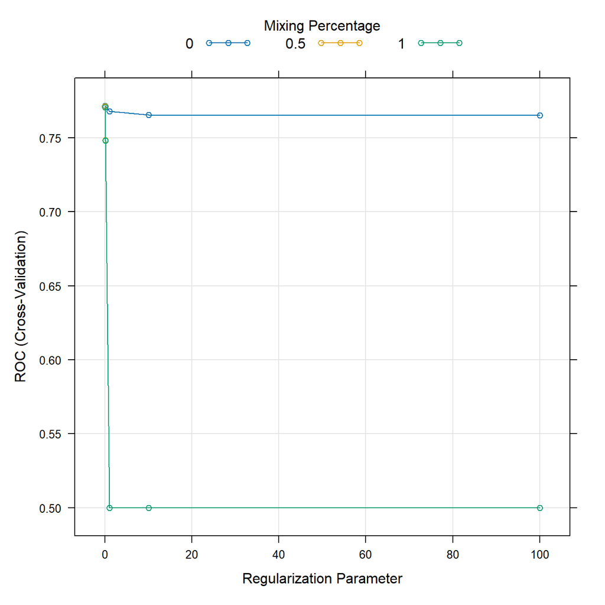

```r
> # Visualizamos los resultados
> plot(modelo_log2)
```

```r
> # Predicciones
> predicciones <- predict(modelo_log2, datos_test)
>
> # Evaluamos el modelo
> confusionMatrix(predicciones, datos_test$Contactos)
```

```
Confusion Matrix and Statistics

          Reference
Prediction Vivos Muertos
   Vivos    1342       7
   Muertos   520      48

               Accuracy : 0.7251
                 95% CI : (0.7045, 0.745)
    No Information Rate : 0.9713
    P-Value [Acc > NIR] : 1

                  Kappa : 0.1074

 Mcnemar's Test P-Value : <2e-16

            Sensitivity : 0.72073
            Specificity : 0.87273
         Pos Pred Value : 0.99481
         Neg Pred Value : 0.08451
             Prevalence : 0.97131
         Detection Rate : 0.70005
   Detection Prevalence : 0.70370
      Balanced Accuracy : 0.79673

       'Positive' Class : Vivos
```

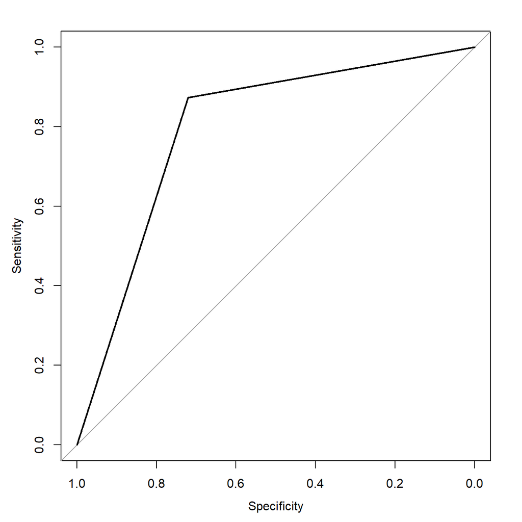

```r
> roc_curve <- roc(datos_test$Contactos, as.numeric(predicciones))
> plot(roc_curve)
```

```r
> auc(roc_curve)
```

```
Area under the curve: 0.7967
```

La optimización mediante validación cruzada ha mejorado el modelo en todas las métricas menos en especificidad (se mantiene) y en el valor AUC.

## Naive Bayes

```r
> # Ajustamos el modelo de Naive Bayes
> modelo_nb <- naiveBayes(Contactos ~ ., data = datos_balanceados, laplace = 0)
>
> # Predicciones
> pred_nb <- predict(modelo_nb, newdata = datos_test)
>
> # Evaluamos el modelo
> confusionMatrix(pred_nb, datos_test$Contactos)
```

```
Confusion Matrix and Statistics

          Reference
Prediction Vivos Muertos
   Vivos    1763      37
   Muertos    99      18

               Accuracy : 0.9291
                 95% CI : (0.9166, 0.9401)
    No Information Rate : 0.9713
    P-Value [Acc > NIR] : 1

                  Kappa : 0.1772

 Mcnemar's Test P-Value : 1.689e-07

            Sensitivity : 0.9468
            Specificity : 0.3273
         Pos Pred Value : 0.9794
         Neg Pred Value : 0.1538
             Prevalence : 0.9713
         Detection Rate : 0.9197
   Detection Prevalence : 0.9390
      Balanced Accuracy : 0.6371

       'Positive' Class : Vivos
```

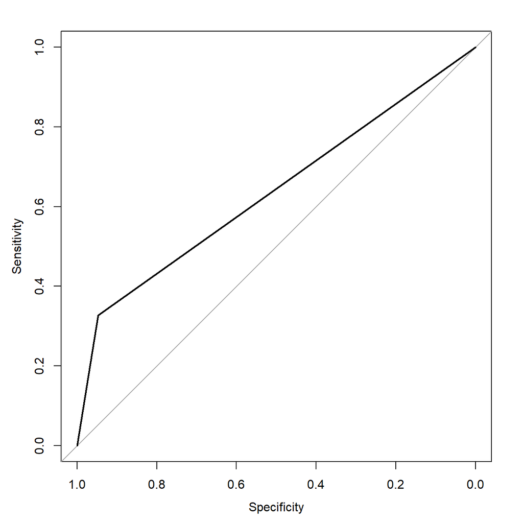

```r
> roc_curve <- roc(datos_test$Contactos, as.numeric(pred_nb))
> plot(roc_curve)
```

```r
> auc(roc_curve)
```

```
Area under the curve: 0.6371
```

### Ajuste del modelo de Naive Bayes

```r
> # Configuramos la validación cruzada
> control <- trainControl(method = "cv", number = 10)  # 10 particiones de validación cruzada
>
> # Definimos la rejilla de hiperparámetros
> grid <- expand.grid(
+   fL = seq(0, 2, by = 0.5),         # Valores de suavizado Laplace
+   usekernel = c(TRUE, FALSE),       # Usar o no kernel
+   adjust = seq(0.5, 1.5, by = 0.5)  # Ajuste del ancho de banda del kernel
+ )
>
> # Entrenamos el modelo Naive Bayes
> modelo_tuned <- train(
+   Contactos ~ .,                    # Fórmula del modelo
+   data = datos_balanceados,         # Conjunto de datos de entrenamiento
+   method = "nb",                    # Método Naive Bayes
+   trControl = control,              # Configuración de validación cruzada
+   tuneGrid = grid                   # Rejilla de hiperparámetros
+ )
>
> # Vemos los mejores hiperparámetros
> print(modelo_tuned$bestTune)
```

```
  fL usekernel adjust
5  0      TRUE      1
```

```r
> # Vemos resultados por combinación de hiperparámetros
> print(modelo_tuned$results)
```

```
    fL usekernel adjust  Accuracy     Kappa AccuracySD    KappaSD
1  0.0     FALSE    0.5 0.7235558 0.4483975 0.02196983 0.04391400
2  0.0     FALSE    1.0 0.7235558 0.4483975 0.02196983 0.04391400
3  0.0     FALSE    1.5 0.7235558 0.4483975 0.02196983 0.04391400
4  0.0      TRUE    0.5 0.7870181 0.5739276 0.02453982 0.04905020
5  0.0      TRUE    1.0 0.7894785 0.5790050 0.02089565 0.04178511
6  0.0      TRUE    1.5 0.7892538 0.5787423 0.02146833 0.04296024
7  0.5     FALSE    0.5 0.7235558 0.4483975 0.02196983 0.04391400
8  0.5     FALSE    1.0 0.7235558 0.4483975 0.02196983 0.04391400
9  0.5     FALSE    1.5 0.7235558 0.4483975 0.02196983 0.04391400
10 0.5      TRUE    0.5 0.7870181 0.5739276 0.02453982 0.04905020
11 0.5      TRUE    1.0 0.7894785 0.5790050 0.02089565 0.04178511
12 0.5      TRUE    1.5 0.7892538 0.5787423 0.02146833 0.04296024
13 1.0     FALSE    0.5 0.7235558 0.4483975 0.02196983 0.04391400
14 1.0     FALSE    1.0 0.7235558 0.4483975 0.02196983 0.04391400
```

[output cut: 16 more lines]

```r
> # Predicciones
> predicciones <- predict(modelo_tuned, datos_test)
>
> # Evaluamos el modelo
> confusionMatrix(predicciones, datos_test$Contactos)
```

```
Confusion Matrix and Statistics

          Reference
Prediction Vivos Muertos
   Vivos    1530      11
   Muertos   332      44

               Accuracy : 0.8211
                 95% CI : (0.8032, 0.838)
    No Information Rate : 0.9713
    P-Value [Acc > NIR] : 1

                  Kappa : 0.1622

 Mcnemar's Test P-Value : <2e-16

            Sensitivity : 0.8217
            Specificity : 0.8000
         Pos Pred Value : 0.9929
         Neg Pred Value : 0.1170
             Prevalence : 0.9713
         Detection Rate : 0.7981
   Detection Prevalence : 0.8039
      Balanced Accuracy : 0.8108

       'Positive' Class : Vivos
```

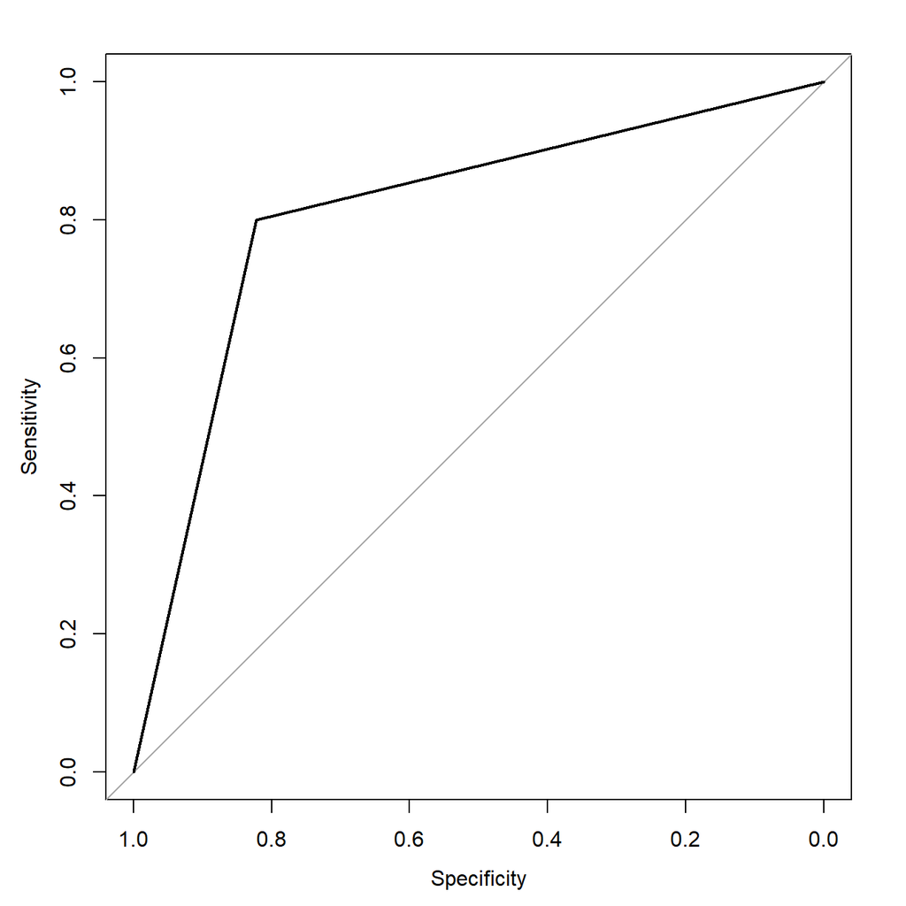

```r
> roc_curve <- roc(datos_test$Contactos, as.numeric(predicciones))
> plot(roc_curve)
```

```r
> auc(roc_curve)
```

```
Area under the curve: 0.8108
```

Ajustando los hiperparámetros del modelo mediante la validación cruzada se produce una mejora clara en la métrica de especificidad y en el valor AUC a costa de perder precisión y sensibilidad.

## SVM

```r
> # Ajustamos modelo SVM con un kernel lineal
> modelo_svm <- svm(Contactos ~ ., data = datos_balanceados, kernel = "linear")
>
> # Predicciones
> pred_svm <- predict(modelo_svm, newdata = datos_test)
>
> # Evaluamos el modelo
> confusionMatrix(pred_svm, datos_test$Contactos)
```

```
Confusion Matrix and Statistics

          Reference
Prediction Vivos Muertos
   Vivos    1527       9
   Muertos   335      46

               Accuracy : 0.8206
                 95% CI : (0.8026, 0.8375)
    No Information Rate : 0.9713
    P-Value [Acc > NIR] : 1

                  Kappa : 0.1694

 Mcnemar's Test P-Value : <2e-16

            Sensitivity : 0.8201
            Specificity : 0.8364
         Pos Pred Value : 0.9941
         Neg Pred Value : 0.1207
             Prevalence : 0.9713
         Detection Rate : 0.7966
   Detection Prevalence : 0.8013
      Balanced Accuracy : 0.8282

       'Positive' Class : Vivos
```

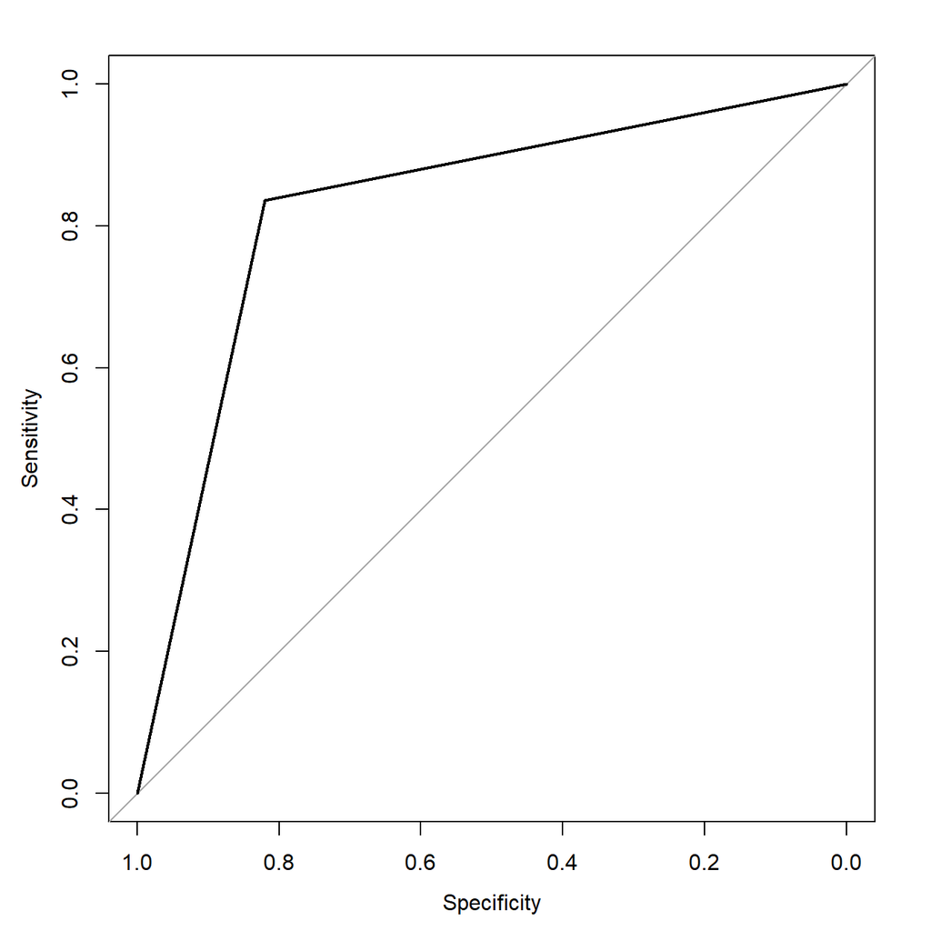

```r
> roc_curve <- roc(datos_test$Contactos, as.numeric(pred_svm))
> plot(roc_curve)
```

```r
> auc(roc_curve)
```

```
Area under the curve: 0.8282
```

### Ajuste del modelo de SVM

```r
> # Calculamos sigma usando la función sigest de kernlab
> sigma_est <- sigest(Contactos ~ ., data = datos_balanceados, frac = 0.75)
>
> # Configuramos el grid de hiperparámetros
> grid <- expand.grid(
+   C = c(0.1, 1, 10, 100),                              # Valores para C
+   sigma = c(sigma_est[1], sigma_est[2], sigma_est[3])  # Rango sugerido para sigma
+ )
>
> # Configuramos la validación cruzada
> control <- trainControl(
+   method = "cv",
+   number = 5,
+   classProbs = TRUE,
+   summaryFunction = twoClassSummary
+ )
>
> # Entrenamos el modelo SVM con kernel radial
> modelo_svm <- train(
+   Contactos ~ .,
+   data = datos_balanceados,
+   method = "svmRadial",
+   metric = "ROC",
+   tuneGrid = grid,
+   trControl = control
+ )
>
> # Mejor combinación de hiperparámetros
> print(modelo_svm$bestTune)
```

```
      sigma  C
9 0.1321061 10
```

```r
> # Predicciones
> predicciones <- predict(modelo_svm, datos_test)
>
> # Evaluamos el modelo
> confusionMatrix(predicciones, datos_test$Contactos)
```

```
Confusion Matrix and Statistics

          Reference
Prediction Vivos Muertos
   Vivos    1170       7
   Muertos   692      48

               Accuracy : 0.6354
                 95% CI : (0.6134, 0.657)
    No Information Rate : 0.9713
    P-Value [Acc > NIR] : 1

                  Kappa : 0.0711

 Mcnemar's Test P-Value : <2e-16

            Sensitivity : 0.62836
            Specificity : 0.87273
         Pos Pred Value : 0.99405
         Neg Pred Value : 0.06486
             Prevalence : 0.97131
         Detection Rate : 0.61033
   Detection Prevalence : 0.61398
      Balanced Accuracy : 0.75054

       'Positive' Class : Vivos
```

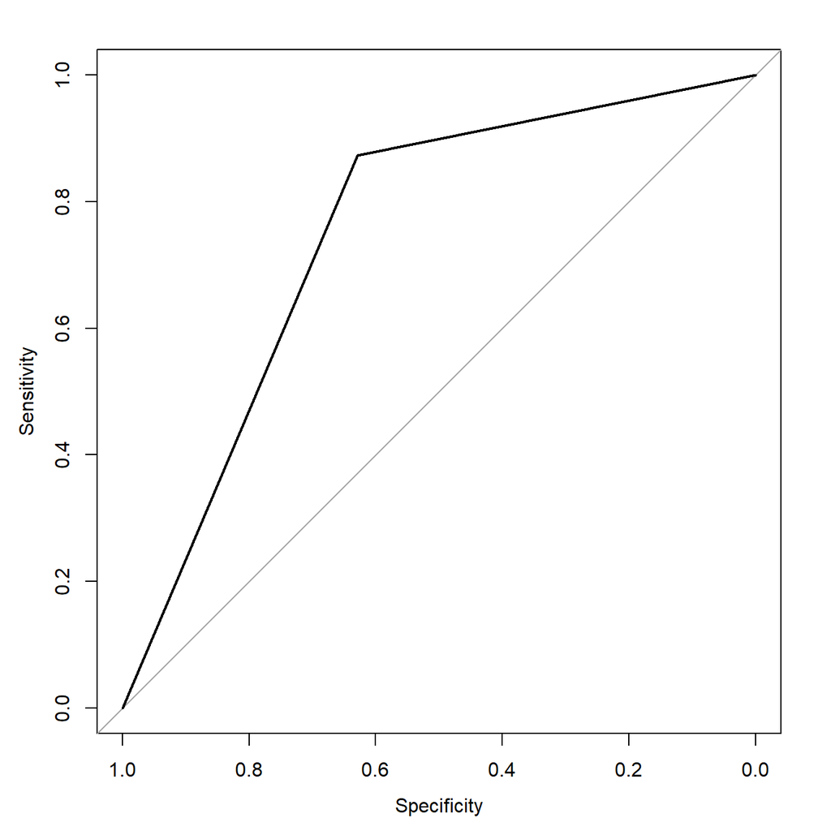

```r
> roc_curve <- roc(datos_test$Contactos, as.numeric(predicciones))
> plot(roc_curve)
```

```r
> auc(roc_curve)
```

```
Area under the curve: 0.7505
```

Ajustando los hiperparámetros del modelo mediante la validación cruzada se produce un empeoramiento de la mayoría de las métricas (excepto la especificidad).

## Árboles de decisión

```r
> # Ajustamos árbol de decisión
> modelo_arbol <- rpart(Contactos ~ ., data = datos_balanceados, method = "class")
>
> # Predicciones
> pred_arbol <- predict(modelo_arbol, newdata = datos_test, type = "class")
>
> # Evaluamos el modelo
> confusionMatrix(pred_arbol, datos_test$Contactos)
```

```
Confusion Matrix and Statistics

          Reference
Prediction Vivos Muertos
   Vivos    1511       9
   Muertos   351      46

               Accuracy : 0.8122
                 95% CI : (0.794, 0.8295)
    No Information Rate : 0.9713
    P-Value [Acc > NIR] : 1

                  Kappa : 0.1613

 Mcnemar's Test P-Value : <2e-16

            Sensitivity : 0.8115
            Specificity : 0.8364
         Pos Pred Value : 0.9941
         Neg Pred Value : 0.1159
             Prevalence : 0.9713
         Detection Rate : 0.7882
   Detection Prevalence : 0.7929
      Balanced Accuracy : 0.8239

       'Positive' Class : Vivos
```

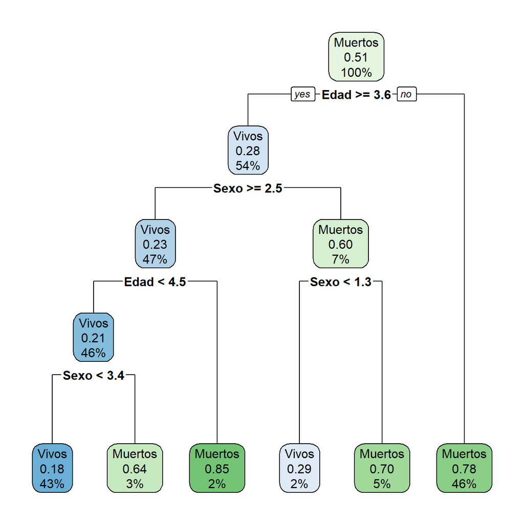

```r
> # Visualizamos el árbol
> rpart.plot(modelo_arbol)
```

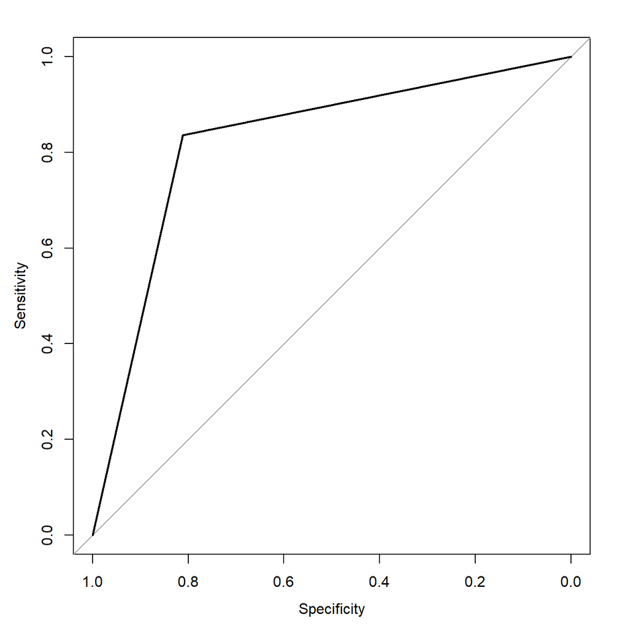

```r
> roc_curve <- roc(datos_test$Contactos, as.numeric(pred_arbol))
> plot(roc_curve)
```

```r
> auc(roc_curve)
```

```
Area under the curve: 0.8239
```

### Ajuste del modelo de árbol de decisiones

```r
> # Configuramos la validación cruzada de 10 pliegues
> ctrl <- trainControl(method = "cv", number = 10, search = "grid", classProbs = TRUE, summaryFunction = twoClassSummary)
>
> # Definimos la cuadrícula de hiperparámetros para explorar
> grid_cp <- expand.grid(
+   cp = seq(0.01, 0.1, by = 0.01)         # Valor de cp entre 0.01 y 0.1
+ )
>
> # Valores para maxdepth y minsplit
> valores_maxdepth <- c(5, 10, 15)  # Profundidad máxima
> valores_minsplit <- c(10, 20)     # Número mínimo de observaciones para dividir un nodo
>
> # Creamos una lista para almacenar resultados
> resultados <- list()
> mejor_auc <- 0  # Para rastrear el mejor modelo
>
>
> # Bucle para ajustar maxdepth y minsplit
> for (maxd in valores_maxdepth) {
+   for (mins in valores_minsplit) {
+
+     # Configuramos el control manual con rpart.control()
+     control <- rpart.control(maxdepth = maxd, minsplit = mins)
+
+     # Entrenamos el modelo con caret y ajustamos el cp
+     modelo <- train(
+       Contactos ~ .,
+       data = datos_balanceados,
+       method = "rpart",
+       trControl = ctrl,
+       tuneGrid = grid_cp,
+       metric = "ROC",
+       control = control # Configuración de maxdepth y minsplit
+     )
+
+     # Evaluamos el modelo
+     auc_actual <- max(modelo$results$ROC)
+
+     # Guardamos el mejor modelo
+     if (auc_actual > mejor_auc) {
+       mejor_auc <- auc_actual
+       mejor_modelo <- modelo
+       mejor_params <- list(maxdepth = maxd, minsplit = mins, cp = modelo$bestTune$cp)
+     }
+
+     # Guardamos los resultados de este ajuste
+     resultados[[paste("maxdepth", maxd, "minsplit", mins)]] <- list(
+       modelo = modelo,
+       auc = auc_actual
+     )
+   }
+ }
>
> # Mostramos el mejor modelo y parámetros encontrados
> print(paste("Mejor AUC:", mejor_auc))
```

```
[1] "Mejor AUC: 0.793208107369015"
```

```r
> print(mejor_params)
```

```
$maxdepth
[1] 15

$minsplit
[1] 20

$cp
[1] 0.01
```

```r
> # Predicciones
> pred_arbol_controlado <- predict(mejor_modelo, newdata = datos_test)
>
> # Evaluamos el modelo
> confusionMatrix(pred_arbol_controlado, datos_test$Contactos)
```

```
Confusion Matrix and Statistics

          Reference
Prediction Vivos Muertos
   Vivos    1511       9
   Muertos   351      46

               Accuracy : 0.8122
                 95% CI : (0.794, 0.8295)
    No Information Rate : 0.9713
    P-Value [Acc > NIR] : 1

                  Kappa : 0.1613

 Mcnemar's Test P-Value : <2e-16

            Sensitivity : 0.8115
            Specificity : 0.8364
         Pos Pred Value : 0.9941
         Neg Pred Value : 0.1159
             Prevalence : 0.9713
         Detection Rate : 0.7882
   Detection Prevalence : 0.7929
      Balanced Accuracy : 0.8239

       'Positive' Class : Vivos
```

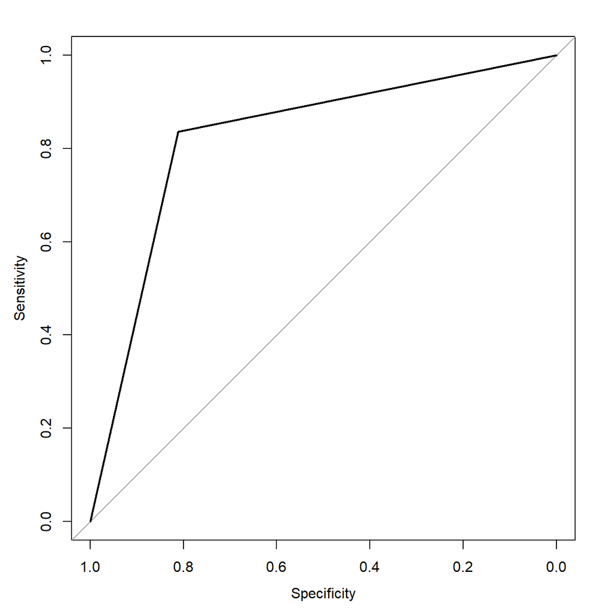

```r
> roc_curve <- roc(datos_test$Contactos, as.numeric(pred_arbol_controlado))
> plot(roc_curve)
```

```r
> auc(roc_curve)
```

```
Area under the curve: 0.8239
```

Ajustando los hiperparámetros del modelo mediante la validación cruzada no se produce mejora en las métricas del modelo.

## Random Forest

```r
> # Establecemos la semilla
> set.seed(12345)
>
> # Ajustamos modelo Random Forest
> modelo_rf <- randomForest(Contactos ~ ., data = datos_balanceados, ntree = 100, importance = TRUE)
>
> # Predicciones
> pred_rf <- predict(modelo_rf, newdata = datos_test)
>
> # Evaluamos el modelo
> confusionMatrix(pred_rf, datos_test$Contactos)
```

```
Confusion Matrix and Statistics

          Reference
Prediction Vivos Muertos
   Vivos    1552      10
   Muertos   310      45

               Accuracy : 0.8331
                 95% CI : (0.8156, 0.8495)
    No Information Rate : 0.9713
    P-Value [Acc > NIR] : 1

                  Kappa : 0.1787

 Mcnemar's Test P-Value : <2e-16

            Sensitivity : 0.8335
            Specificity : 0.8182
         Pos Pred Value : 0.9936
         Neg Pred Value : 0.1268
             Prevalence : 0.9713
         Detection Rate : 0.8096
   Detection Prevalence : 0.8148
      Balanced Accuracy : 0.8258

       'Positive' Class : Vivos
```

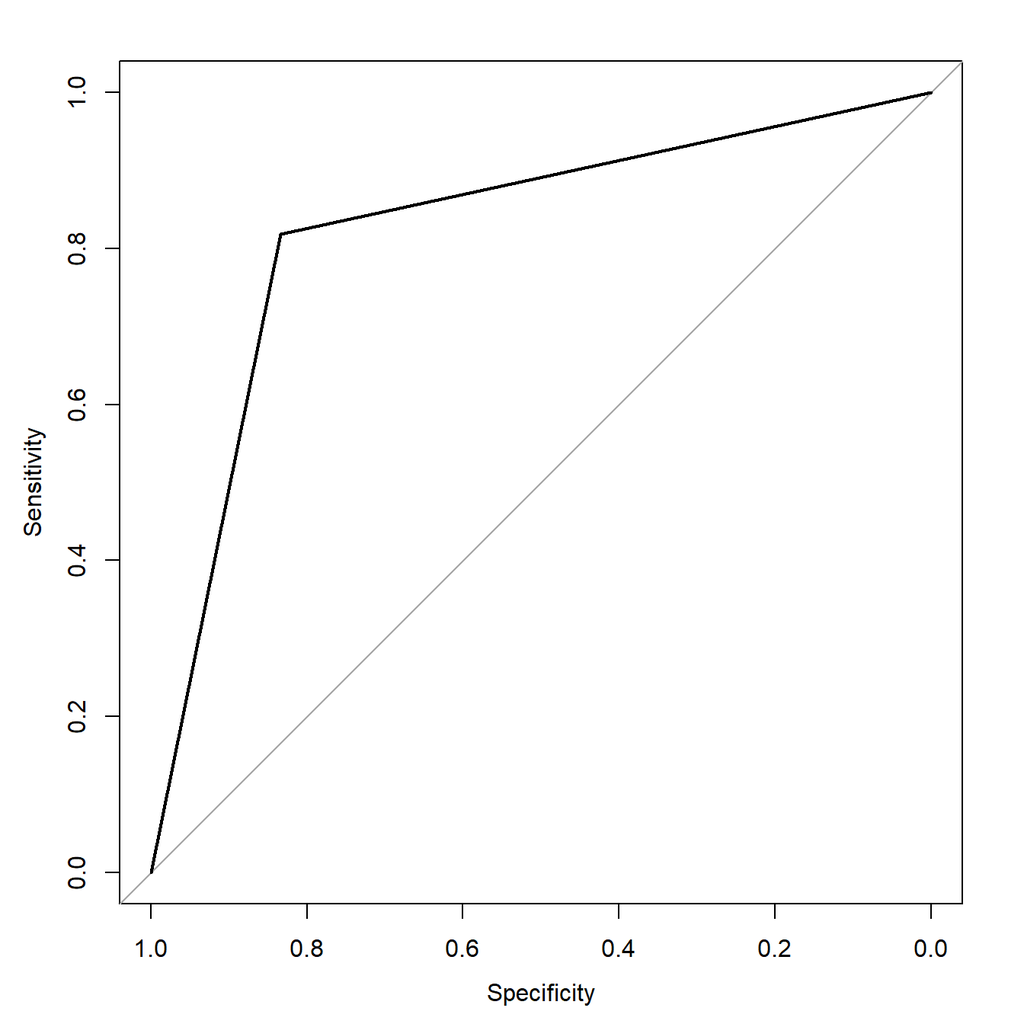

```r
> roc_curve <- roc(datos_test$Contactos, as.numeric(pred_rf))
> plot(roc_curve)
```

```r
> auc(roc_curve)
```

```
Area under the curve: 0.8258
```

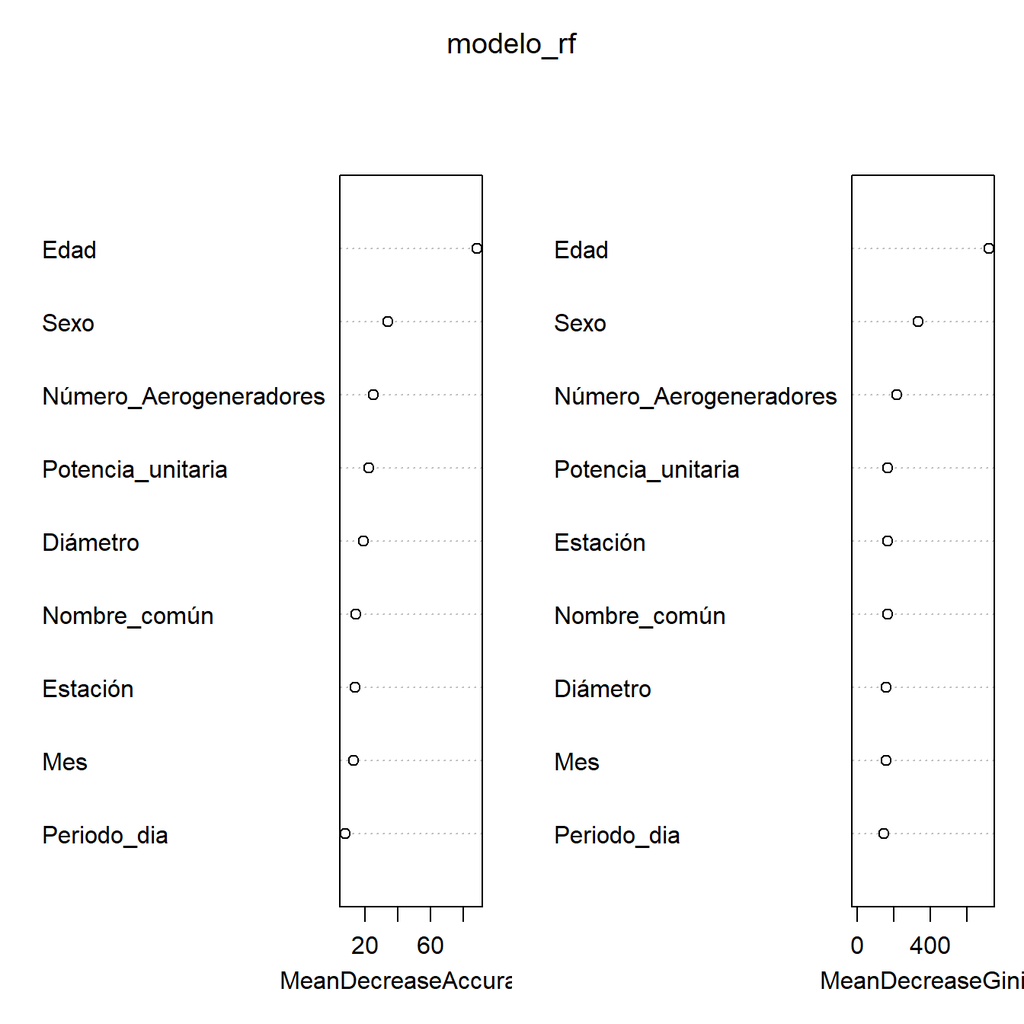

```r
> # Importancia de las variables
> varImpPlot(modelo_rf)
```

### Ajuste del modelo de Random Forest

```r
> # Establecemos la semilla
> set.seed(12345)
>
> # Configuramos la validación cruzada
> control <- trainControl(
+   method = "repeatedcv",  # Validación cruzada repetida
+   number = 10,           # Número de particiones (folds)
+   repeats = 5,           # Número de repeticiones
+   search = "grid"        # Búsqueda en cuadrícula
+ )
>
> # Creamos la cuadrícula de búsqueda
> parametros <- expand.grid(
+   mtry = c(2, 4, 6, 8)       # Número de predictores a probar en cada división
+ )
>
> # Entrenamos el modelo Random Forest con búsqueda de hiperparámetros
> modelo_rf2 <- train(
+   Contactos ~ .,            # Fórmula del modelo
+   data = datos_balanceados, # Datos de entrenamiento
+   method = "rf",            # Especificar Random Forest
+   trControl = control,      # Esquema de validación cruzada
+   tuneGrid = parametros,    # Rango de hiperparámetros
+   ntree = 500               # Número de árboles fijo
+ )
>
> # Mejor modelo y resultados
> print(modelo_rf2)
```

```
Random Forest

4475 samples
   9 predictor
   2 classes: 'Vivos', 'Muertos'

No pre-processing
Resampling: Cross-Validated (10 fold, repeated 5 times)
Summary of sample sizes: 4027, 4028, 4028, 4028, 4028, 4028, ...
Resampling results across tuning parameters:

  mtry  Accuracy   Kappa
  2     0.8239538  0.6474924
  4     0.8244014  0.6483827
  6     0.8240893  0.6477485
  8     0.8214510  0.6424778

Accuracy was used to select the optimal model using the largest value.
The final value used for the model was mtry = 4.
```

```r
> # Mostramos el mejor valor de mtry
> best_mtry <- modelo_rf2$bestTune
> best_mtry
```

|  | mtry |
| --- | --- |
| 2 | 4 |

```r
> # Predicciones
> pred_rf2 <- predict(modelo_rf2, newdata = datos_test)
>
> # Evaluamos el modelo
> confusionMatrix(pred_rf2, datos_test$Contactos)
```

```
Confusion Matrix and Statistics

          Reference
Prediction Vivos Muertos
   Vivos    1558       9
   Muertos   304      46

               Accuracy : 0.8367
                 95% CI : (0.8194, 0.853)
    No Information Rate : 0.9713
    P-Value [Acc > NIR] : 1

                  Kappa : 0.1868

 Mcnemar's Test P-Value : <2e-16

            Sensitivity : 0.8367
            Specificity : 0.8364
         Pos Pred Value : 0.9943
         Neg Pred Value : 0.1314
             Prevalence : 0.9713
         Detection Rate : 0.8127
   Detection Prevalence : 0.8174
      Balanced Accuracy : 0.8365

       'Positive' Class : Vivos
```

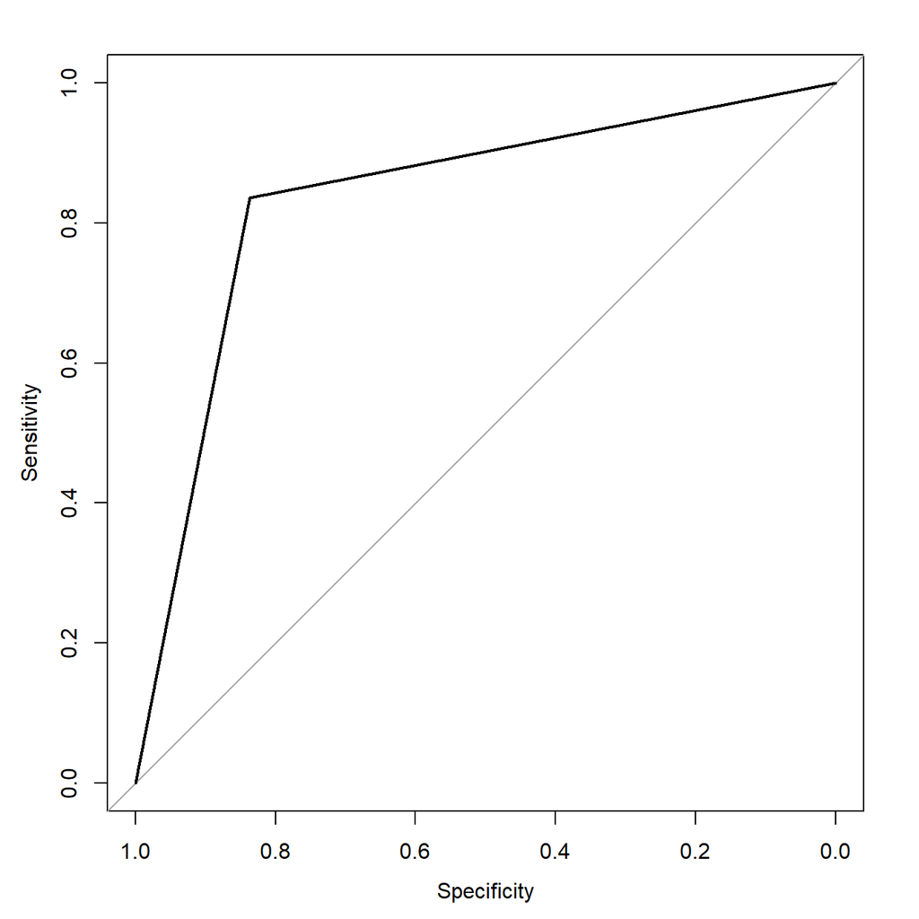

```r
> roc_curve <- roc(datos_test$Contactos, as.numeric(pred_rf2))
> plot(roc_curve)
```

```r
> auc(roc_curve)
```

```
Area under the curve: 0.8365
```

Ajustando los hiperparámetros del modelo mediante la validación cruzada se produce una ligera mejora en las métricas del modelo.

## Gradient boosting

```r
> set.seed(12345)
>
> # Convertimos datos en formato matriz para XGBoost
> datos_train_matrix <- as.matrix(datos_balanceados[, -1])  # Sin la columna objetivo
> datos_test_matrix <- as.matrix(datos_test[, -1])
> label_train <- as.numeric(datos_balanceados$Contactos == "Muertos")
> label_test <- as.numeric(datos_test$Contactos == "Muertos")
>
> # Ajustamos modelo XGBoost
> modelo_xgb <- xgboost(data = datos_train_matrix, label = label_train, nrounds = 100, objective = "binary:logistic", eval_metric = "auc")
> # Predicciones
> pred_xgb <- predict(modelo_xgb, newdata = datos_test_matrix, iteration_range = c(1, modelo_xgb$best_ntreelimit))
> pred_clases_xgb <- ifelse(pred_xgb > 0.5, "Muertos", "Vivos")
>
> # Evaluamos el modelo
> confusionMatrix(as.factor(pred_clases_xgb), datos_test$Contactos)
```

```
Confusion Matrix and Statistics

          Reference
Prediction Vivos Muertos
   Vivos    1603      11
   Muertos   259      44

               Accuracy : 0.8592
                 95% CI : (0.8428, 0.8744)
    No Information Rate : 0.9713
    P-Value [Acc > NIR] : 1

                  Kappa : 0.2073

 Mcnemar's Test P-Value : <2e-16

            Sensitivity : 0.8609
            Specificity : 0.8000
         Pos Pred Value : 0.9932
         Neg Pred Value : 0.1452
             Prevalence : 0.9713
         Detection Rate : 0.8362
   Detection Prevalence : 0.8419
      Balanced Accuracy : 0.8305

       'Positive' Class : Vivos
```

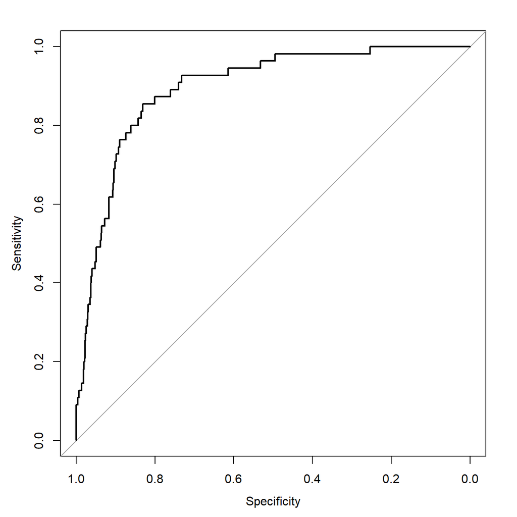

```r
> roc_curve <- roc(datos_test$Contactos, pred_xgb)
> plot(roc_curve)
```

```r
> auc(roc_curve)
```

```
Area under the curve: 0.8955
```

# Ajuste del modelo Gradient Boosting

```r
> # Establecemos la semilla
> set.seed(12345)
>
> # Creamos las matrices de entrenamiento y prueba
> dtrain <- xgb.DMatrix(data = as.matrix(datos_balanceados[, -1]), label = as.numeric(datos_balanceados$Contactos) - 1)
> dtest <- xgb.DMatrix(data = as.matrix(datos_test[, -1]), label = as.numeric(datos_test$Contactos) - 1)
>
> # Data table para almacenar resultados
> results <- data.table()
>
> # Creamos el grid de hiperparámetros
> param_grid <- expand.grid(
+   eta = c(0.01, 0.05, 0.1, 0.2),
+   max_depth = c(3, 6, 9),
+   gamma = c(0, 0.1, 0.2),
+   colsample_bytree = c(0.6, 0.8, 1),
+   min_child_weight = c(1, 3, 5),
+   subsample = c(0.6, 0.8, 1)
+ )
>
> # Evaluamos cada combinación de hiperparámetros
> evaluate_model <- function(params, dtrain, dtest) {
+   # Validación cruzada con xgb.cv
+   cv <- xgb.cv(
+     params = params,
+     data = dtrain,
+     nrounds = 1000,
+     nfold = 5,
+     maximize = TRUE,
+     early_stopping_rounds = 50,
+     eval_metric = "auc",
+     verbose = FALSE
+   )
+
+   # Extraemos el mejor AUC y número de iteraciones
+   best_auc <- max(cv$evaluation_log$test_auc_mean)
+   best_nrounds <- cv$best_iteration
+
+   return(list(auc = best_auc, nrounds = best_nrounds))
+ }
>
> # Bucle con retroalimentación de progreso
> results <- pblapply(1:nrow(param_grid), function(i) {
+   params <- as.list(param_grid[i, ])
+   params$objective <- "binary:logistic"
+
+   # Evaluamos el modelo con los parámetros actuales
+   eval_result <- evaluate_model(params, dtrain, dtest)
+
+   # Guardamos los resultados
+   return(data.table(
+     eta = params$eta,
+     max_depth = params$max_depth,
+     gamma = params$gamma,
+     colsample_bytree = params$colsample_bytree,
+     min_child_weight = params$min_child_weight,
+     subsample = params$subsample,
+     auc = eval_result$auc,
+     nrounds = eval_result$nrounds
+   ))
+ })
>
> # Convertimos la lista de resultados en una tabla
> results <- rbindlist(results)
>
> # Ordenamos los resultados por AUC
> best_result <- results[order(-auc)][1]
> print(best_result)
```

```
     eta max_depth gamma colsample_bytree min_child_weight subsample       auc
   <num>     <num> <num>            <num>            <num>     <num>     <num>
1:  0.01         6   0.1              0.8                1       0.8 0.9061865
   nrounds
     <int>
1:     999
```

```r
> # Entrenamos el modelo final con los mejores hiperparámetros
> best_params <- as.list(best_result[, .(eta, max_depth, gamma, colsample_bytree, min_child_weight, subsample)])
> best_params$objective <- "binary:logistic"
> best_params$eval_metric <- "auc"
>
> modelo_xgb3 <- xgb.train(
+   params = best_params,
+   data = dtrain,
+   nrounds = best_result$nrounds,
+   watchlist = list(train = dtrain, test = dtest),
+   maximize = TRUE,
+   verbose = TRUE
+ )
> # Predicciones
> pred_xgb3 <- predict(modelo_xgb3, newdata = datos_test_matrix)
> pred_clases_xgb3 <- ifelse(pred_xgb3 > 0.5, "Muertos", "Vivos")
>
> # Evaluamos el modelo final
> confusionMatrix(as.factor(pred_clases_xgb3), datos_test$Contactos)
```

```
Confusion Matrix and Statistics

          Reference
Prediction Vivos Muertos
   Vivos    1584      12
   Muertos   278      43

               Accuracy : 0.8487
                 95% CI : (0.8319, 0.8645)
    No Information Rate : 0.9713
    P-Value [Acc > NIR] : 1

                  Kappa : 0.189

 Mcnemar's Test P-Value : <2e-16

            Sensitivity : 0.8507
            Specificity : 0.7818
         Pos Pred Value : 0.9925
         Neg Pred Value : 0.1340
             Prevalence : 0.9713
         Detection Rate : 0.8263
   Detection Prevalence : 0.8326
      Balanced Accuracy : 0.8163

       'Positive' Class : Vivos
```

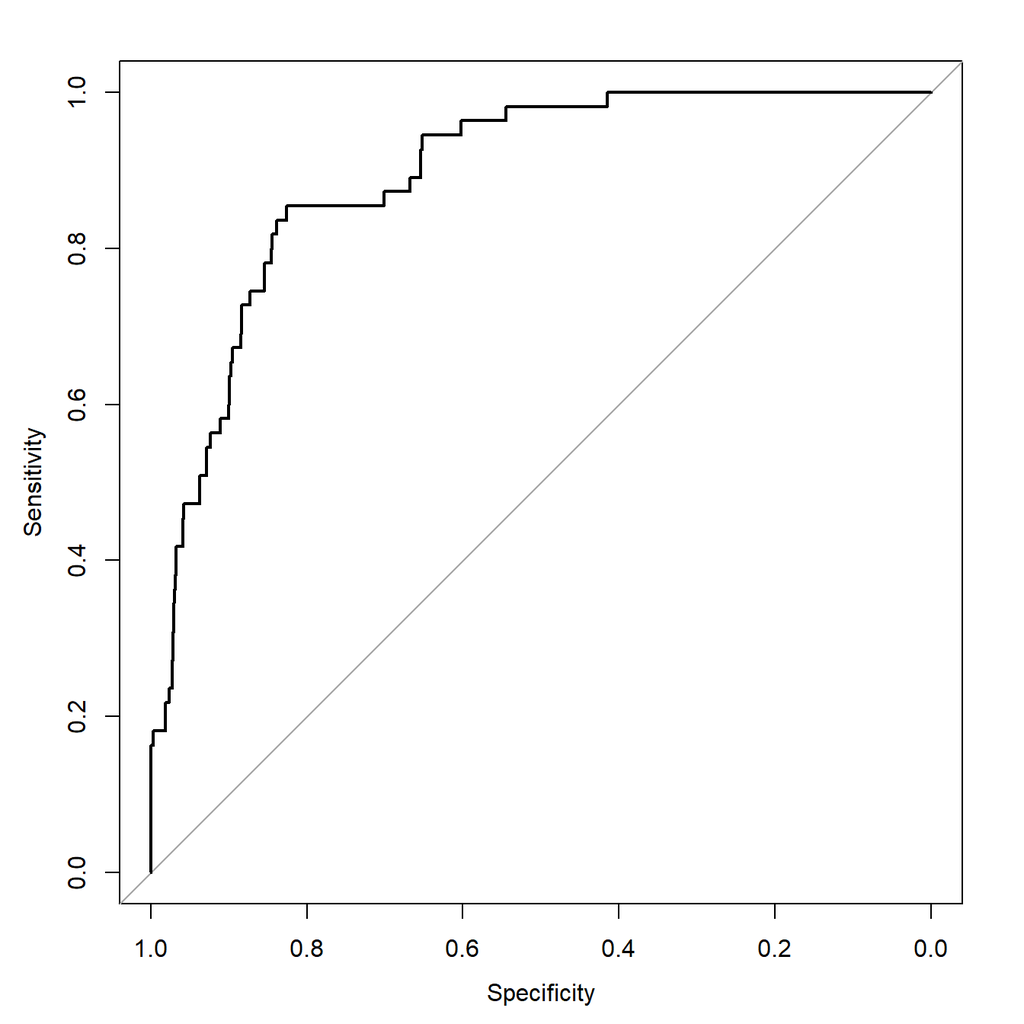

```r
> roc_curve <- roc(datos_test$Contactos, pred_xgb3)
> plot(roc_curve)
```

```r
> auc(roc_curve)
```

```
Area under the curve: 0.8919
```

Ajustando los hiperparámetros del modelo mediante la validación cruzada se produce un ligero empeoramiento en las métricas

## Redes Neuronales

```r
> # Establecemos la semilla
> set.seed(12345)
>
> # Ajustamos red neuronal
> modelo_nn <- nnet(Contactos ~ ., data = datos_train, size = 5, decay = 0.01)
> # Predicciones
> pred_nn <- predict(modelo_nn, newdata = datos_test, type = "class")
>
> # Convertimos pred_nn a factor
> pred_nn <- factor(pred_nn, levels = levels(datos_test$Contactos))
>
> # Evaluamos el modelo
> confusionMatrix(pred_nn, datos_test$Contactos)
```

```
Confusion Matrix and Statistics

          Reference
Prediction Vivos Muertos
   Vivos    1861      55
   Muertos     1       0

               Accuracy : 0.9708
                 95% CI : (0.9622, 0.9779)
    No Information Rate : 0.9713
    P-Value [Acc > NIR] : 0.5893

                  Kappa : -0.001

 Mcnemar's Test P-Value : 1.417e-12

            Sensitivity : 0.9995
            Specificity : 0.0000
         Pos Pred Value : 0.9713
         Neg Pred Value : 0.0000
             Prevalence : 0.9713
         Detection Rate : 0.9708
   Detection Prevalence : 0.9995
      Balanced Accuracy : 0.4997

       'Positive' Class : Vivos
```

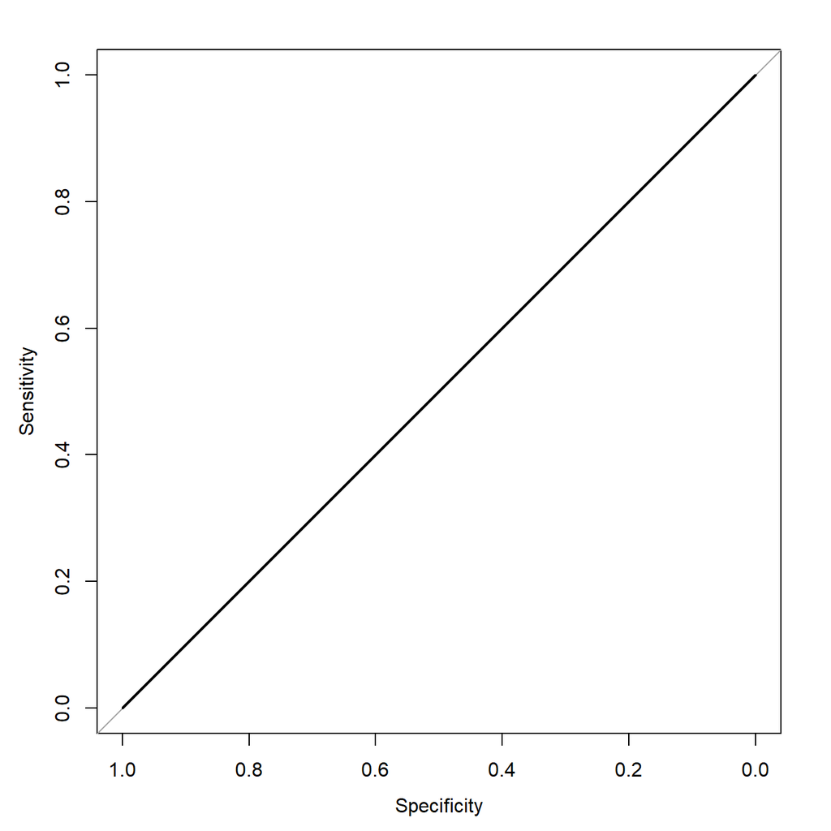

```r
> roc_curve <- roc(datos_test$Contactos, as.numeric(pred_nn))
> plot(roc_curve)
```

```r
> auc(roc_curve)
```

```
Area under the curve: 0.4997
```

### Ajuste del modelo de Redes Neuronales

```r
> # Establecemos la semilla
> set.seed(12345)
>
> # Creamos la cuadrícula de parámetros para la búsqueda
> grid <- expand.grid(
+   size = c(5, 10, 15),   # Número de unidades en la capa oculta
+   decay = c(0.1, 0.01)   # Tasa de regularización (decay)
+ )
>
> # Configuramos la validación cruzada
> train_control <- trainControl(
+   method = "cv",          # Usamos validación cruzada
+   number = 5,             # 5 pliegues de validación
+   verboseIter = TRUE      # Mostrar progreso
+ )
>
> # Entrenamos el modelo usando la red neuronal
> modelo_final <- train(
+   Contactos ~ .,            # Variable objetivo
+   data = datos_balanceados, # Datos de entrenamiento
+   method = "nnet",          # Usamos el modelo de red neuronal de nnet
+   trControl = train_control,# Validación cruzada
+   tuneGrid = grid           # Cuadrícula de hiperparámetros
+ )
> # Vemos el resultado de la búsqueda
> print(modelo_final)
```

```
Neural Network

4475 samples
   9 predictor
   2 classes: 'Vivos', 'Muertos'

No pre-processing
Resampling: Cross-Validated (5 fold)
Summary of sample sizes: 3580, 3580, 3580, 3580, 3580
Resampling results across tuning parameters:

  size  decay  Accuracy   Kappa
   5    0.01   0.6612291  0.3174480
   5    0.10   0.6782123  0.3529106
  10    0.01   0.6163128  0.2234254
  10    0.10   0.6860335  0.3709327
  15    0.01   0.6636872  0.3216890
  15    0.10   0.6225698  0.2389858

Accuracy was used to select the optimal model using the largest value.
The final values used for the model were size = 10 and decay = 0.1.
```

```r
> # Predicción con el mejor modelo encontrado
> predicciones <- predict(modelo_final, newdata = datos_test)
>
> # Evaluamos el rendimiento
> confusionMatrix(predicciones, datos_test$Contactos)
```

```
Confusion Matrix and Statistics

          Reference
Prediction Vivos Muertos
   Vivos    1811      45
   Muertos    51      10

               Accuracy : 0.9499
                 95% CI : (0.9392, 0.9593)
    No Information Rate : 0.9713
    P-Value [Acc > NIR] : 1.0000

                  Kappa : 0.1467

 Mcnemar's Test P-Value : 0.6098

            Sensitivity : 0.9726
            Specificity : 0.1818
         Pos Pred Value : 0.9758
         Neg Pred Value : 0.1639
             Prevalence : 0.9713
         Detection Rate : 0.9447
   Detection Prevalence : 0.9682
      Balanced Accuracy : 0.5772

       'Positive' Class : Vivos
```

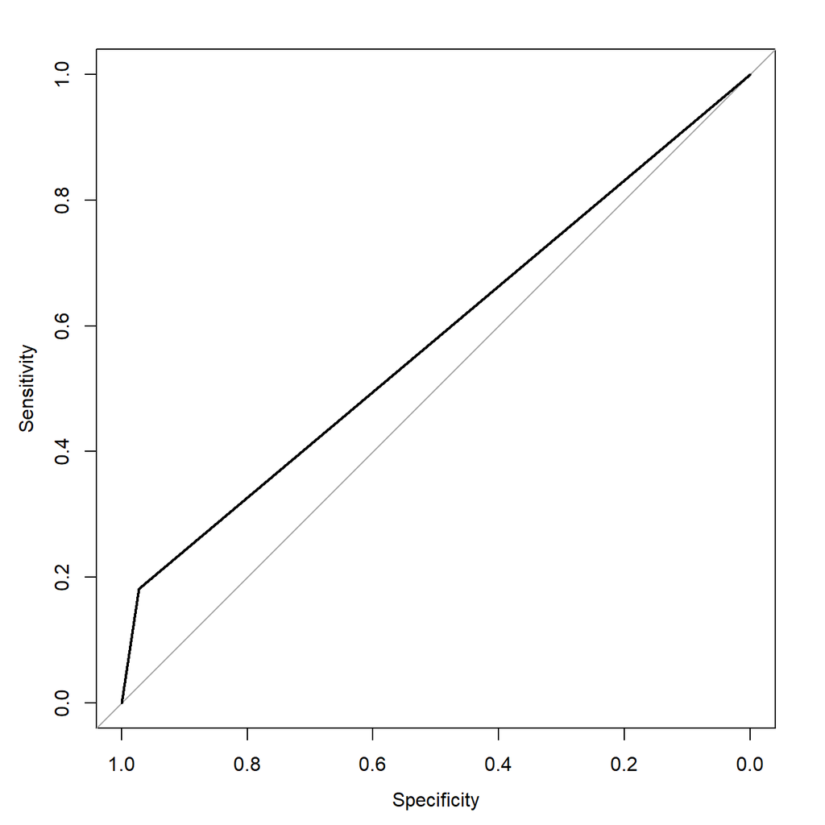

```r
> roc_curve <- roc(datos_test$Contactos, as.numeric(predicciones))
> plot(roc_curve)
```

```r
> auc(roc_curve)
```

```
Area under the curve: 0.5772
```

Ajustando los hiperparámetros del modelo mediante la validación cruzada se produce una mejora en alguna de las métricas del modelo, pero en detrimento de otras.

# Optimización del modelo más preciso

El modelo con mayor precisión es el modelo de Gradient Boosting. Realizamos un procecso de optimización del modelo para mejorar su eficacia. Para ello se utilizará la información de los hiperparámetros recogida en el ajuste del modelo mediante búsqueda de hiperparámetros y validación cruzada y se empleará junto a un grid search refinado, una validación cruzada estratificada y con un incremento en el número de pliegues, el cálculo del umbral óptimo, el incremento en el número de iteraciones.

```r
> # Establecemos la semilla
> set.seed(12345)
>
> # Creamos las matrices de entrenamiento y prueba
> dtrain <- xgb.DMatrix(data = as.matrix(datos_balanceados[, -1]), label = as.numeric(datos_balanceados$Contactos) - 1)
> dtest <- xgb.DMatrix(data = as.matrix(datos_test[, -1]), label = as.numeric(datos_test$Contactos) - 1)
>
> # Data table para almacenar resultados
> results <- data.table()
>
> # Creamos el grid de hiperparámetros
> param_grid <- expand.grid(
+   eta = c(0.005, 0.01, 0.015, 0.02),
+   max_depth = c(5, 6, 7),
+   gamma = c(0.05, 0.1, 0.15),
+   colsample_bytree = c(0.7, 0.8, 0.9),
+   min_child_weight = c(1, 2, 3),
+   subsample = c(0.7, 0.8, 0.9)
+ )
>
> # Evaluamos cada combinación de hiperparámetros
> evaluate_model <- function(params, dtrain, dtest) {
+
+   # Validación cruzada con xgb.cv
+   cv <- xgb.cv(
+     params = params,
+     data = dtrain,
+     nrounds = 2000,
+     nfold = 10,
+     maximize = TRUE,
+     stratified = TRUE,
+     early_stopping_rounds = 50,
+     eval_metric = "auc",
+     verbose = FALSE
+   )
+
+   # Extraemos el mejor AUC y número de iteraciones
+   best_auc <- max(cv$evaluation_log$test_auc_mean)
+   best_nrounds <- cv$best_iteration
+
+   return(list(auc = best_auc, nrounds = best_nrounds))
+ }
>
> # Lista para almacenar resultados
> results <- pblapply(1:nrow(param_grid), function(i) {
+   params <- as.list(param_grid[i, ])
+   params$objective <- "binary:logistic"
+
+   # Evaluamos el modelo con los parámetros actuales
+   eval_result <- evaluate_model(params, dtrain, dtest)
+
+   # Guardamos los resultados
+   return(data.table(
+     eta = params$eta,
+     max_depth = params$max_depth,
+     gamma = params$gamma,
+     colsample_bytree = params$colsample_bytree,
+     min_child_weight = params$min_child_weight,
+     subsample = params$subsample,
+     auc = eval_result$auc,
+     nrounds = eval_result$nrounds
+   ))
+ })
>
> # Convertimos la lista de resultados en una tabla
> results <- rbindlist(results)
>
> # Ordenamos los resultados por AUC
> best_result <- results[order(-auc)][1]
> print(best_result)
```

```
     eta max_depth gamma colsample_bytree min_child_weight subsample       auc
   <num>     <num> <num>            <num>            <num>     <num>     <num>
1:  0.02         5  0.15              0.8                1       0.7 0.9086318
   nrounds
     <int>
1:     820
```

```r
> # Entrenamos el modelo final con los mejores hiperparámetros
> best_params <- as.list(best_result[, .(eta, max_depth, gamma, colsample_bytree, min_child_weight, subsample)])
> best_params$objective <- "binary:logistic"
> best_params$eval_metric <- "auc"
>
> modelo_xgb_final <- xgb.train(
+   params = best_params,
+   data = dtrain,
+   nrounds = best_result$nrounds,
+   watchlist = list(train = dtrain, test = dtest),
+   maximize = TRUE,
+   verbose = TRUE
+ )
> # Función para calcular el umbral óptimo
> optimalThreshold <- function(true_labels, predicted_probs, metric = "F1") {
+   true_labels <- as.factor(true_labels)
+   if (length(levels(true_labels)) != 2) {
+     stop("La variable de etiquetas debe ser binaria.")
+   }
+
+   thresholds <- seq(0, 1, by = 0.01)
+
+   metrics <- sapply(thresholds, function(threshold) {
+     predicted_labels <- ifelse(predicted_probs > threshold, levels(true_labels)[2], levels(true_labels)[1])
+     predicted_labels <- factor(predicted_labels, levels = levels(true_labels))
+
+     confusion <- confusionMatrix(predicted_labels, true_labels)
+
+     if (metric == "F1") {
+       precision <- confusion$byClass["Pos Pred Value"]
+       recall <- confusion$byClass["Sensitivity"]
+       f1 <- 2 * ((precision * recall) / (precision + recall))
+       return(ifelse(is.na(f1), 0, f1))
+     } else if (metric == "Sensitivity") {
+       return(confusion$byClass["Sensitivity"])
+     } else if (metric == "Specificity") {
+       return(confusion$byClass["Specificity"])
+     } else if (metric == "Balanced Accuracy") {
+       sensitivity <- confusion$byClass["Sensitivity"]
+       specificity <- confusion$byClass["Specificity"]
+       return((sensitivity + specificity) / 2)
+     } else {
+       stop("Métrica no reconocida. Usa 'F1', 'Sensitivity', 'Specificity' o 'Balanced Accuracy'.")
+     }
+   })
+
+   best_threshold <- thresholds[which.max(metrics)]
+   return(best_threshold)
+ }
>
> # Predicciones y ajuste del umbral
> pred_xgb <- predict(modelo_xgb_final, newdata = datos_test_matrix)
> optimal_threshold <- optimalThreshold(datos_test$Contactos, pred_xgb, metric = "F1")
> pred_clases_xgb <- ifelse(pred_xgb > optimal_threshold, "Muertos", "Vivos")
>
> # Evaluamos el modelo final
> pred_clases_xgb <- factor(pred_clases_xgb, levels = levels(datos_test$Contactos))
> confusionMatrix(as.factor(pred_clases_xgb), datos_test$Contactos)
```

```
Confusion Matrix and Statistics

          Reference
Prediction Vivos Muertos
   Vivos    1862      49
   Muertos     0       6

               Accuracy : 0.9744
                 95% CI : (0.9663, 0.981)
    No Information Rate : 0.9713
    P-Value [Acc > NIR] : 0.2287

                  Kappa : 0.1922

 Mcnemar's Test P-Value : 7.025e-12

            Sensitivity : 1.0000
            Specificity : 0.1091
         Pos Pred Value : 0.9744
         Neg Pred Value : 1.0000
             Prevalence : 0.9713
         Detection Rate : 0.9713
   Detection Prevalence : 0.9969
      Balanced Accuracy : 0.5545

       'Positive' Class : Vivos
```

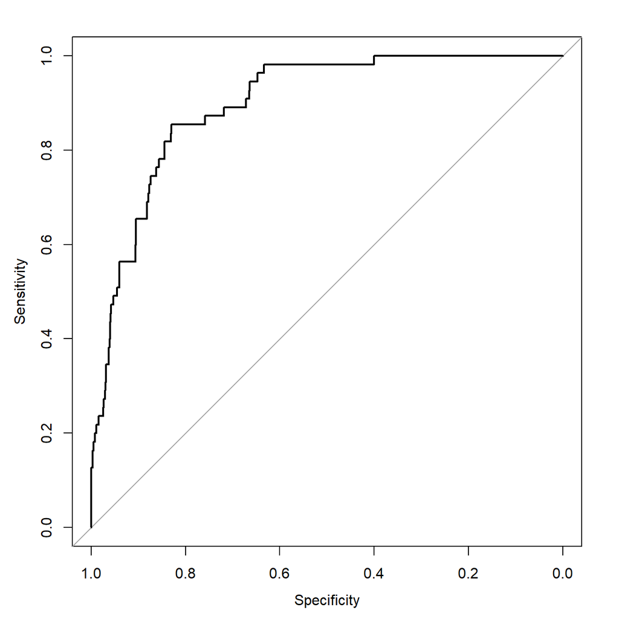

```r
> roc_curve <- roc(datos_test$Contactos, pred_xgb)
> plot(roc_curve)
```

```r
> auc(roc_curve)
```

```
Area under the curve: 0.8977
```